# brian_text

Brian Gilbert

October 18, 2017

First we load the data and put it in a suitable format for sentiment analysis.

```r
data("NYTimes")
NYTimes$Title = as.character(NYTimes$Title)
words = unnest_tokens(NYTimes, word, Title)
nrc.sents = inner_join(words, get_sentiments("nrc"), by="word")
bing.sents = inner_join(words, get_sentiments("bing"), by="word")
```

Now let’s examine matches in the text for each dictionary. Note that the following analyses count the same word multiple times if it appears in multiple headlines, which makes sense if we want to see how the dictionaries are interacting with our specific dataset.

```r
bing.words <- bing.sents %>% select(word)
nrc.words <- nrc.sents %>% filter(sentiment %in% c("positive", "negative")) %>% select(word)
#The above procedure is done to ensure that each token is counted only once. As described below,
#NRC gives a positive/negative value exactly once for each word.
dim(bing.words)[1]
```

```
## [1] 2292
```

```r
dim(nrc.words)[1]
```

```
## [1] 3617
```

The NRC dictionary has significantly more matches in the NYTimes data set. How do the words matched by each dataset compare with respect to length?

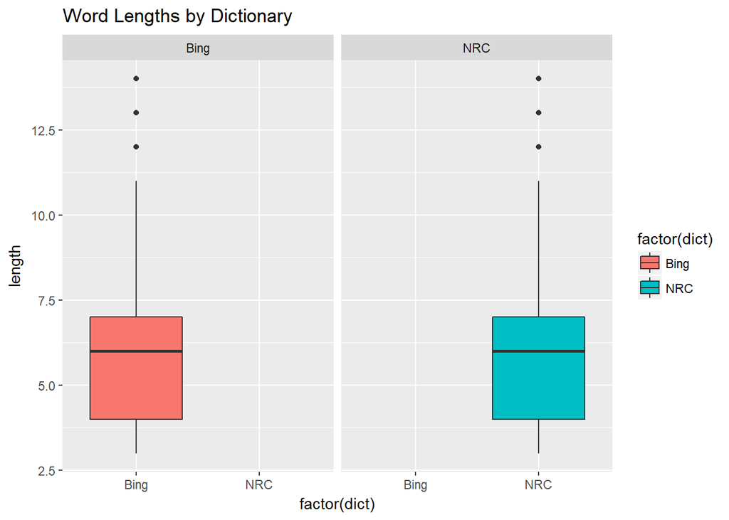

```r
nrc.lengths <- apply(nrc.words, 1, nchar)
bing.lengths <- apply(nrc.words, 1, nchar)
df <- data.frame(length=c(nrc.lengths, bing.lengths), dict = c(rep("NRC", length(nrc.words)), rep("Bing", length(bing.words))))
p <- ggplot(df, aes(x=factor(dict),y=length,fill=factor(dict)))+
  geom_boxplot() + labs(title="Word Lengths by Dictionary") +facet_wrap(~dict)
p
```

Again note that the two dictionaries provide different information corresponding to each word: NRC gives multiple specific sentiments along with a positive/negative characterization, while Bing gives just a binary positive/negative characterization. We may investigate whether these two dictionaries give consistent information by restricting NRC’s responses to positive/negative and looking at words that match both dictionaries.

```r
nrc.binary <- filter(nrc.sents, sentiment %in% c("positive", "negative"))
compare <- inner_join(bing.sents, nrc.binary, by="word", suffix = c(".bing", ".nrc"))
mean(compare$sentiment.bing==compare$sentiment.nrc)
```

```
## [1] 0.9877461
```

The two dictionaries’ sentiments agree 98 percent of the time, but not always. Where do they differ?

```r
compare %>% filter(sentiment.bing != sentiment.nrc) %>% select(word, sentiment.bing, sentiment.nrc)
```

```
##          word sentiment.bing sentiment.nrc
## 1      revive       positive      negative
## 2      revive       positive      negative
## 3      revive       positive      negative
## 4      revive       positive      negative
## 5      revive       positive      negative
## 6      revive       positive      negative
## 7      revive       positive      negative
## 8      revive       positive      negative
## 9     stunned       positive      negative
## 10      tough       positive      negative
## 11      tough       positive      negative
## 12      tough       positive      negative
## 13      tough       positive      negative
## 14      tough       positive      negative
```

[output cut: 108 more lines]

```r
data("NYTimes")
```